# Analysis of editing in brain

Aaron Wagen

UCL

13 February 2024

```r
args <- list(
   detect_summary_comparison_sig_file = here::here("results",
                                                  "brain",
                                                  "jacusa_detect",
                                                  "detect_summary_comparison_sig_edits.RDS"),
   # detect_summary_folder = here::here("results",
   #                                     "brain",
   #                                     "jacusa_detect"),
    sample_annotation_file = here::here("raw_data",
                                        "acta_neuropath_bulk",
                                        "SampleAnnot_metadata.txt"),
    output_folder = here::here("results"),
  lengths_summary_path = here::here("references",
                                    "ensembl93_gene_lengths_summary.RDS"),
  reduced_gtf = here::here("references", "ensembl93_reduced_gtf.RDS")
)



plot_labels = c("Decreased_editing" = "Decreased editing",
                "Increased_editing" = "Increased editing",
                "Lost_edit_sites" = "Lost editing sites",
                "New_edit_sites" = "New editing sites",
                "astro_nt_vs_asyn" = "Astrocyte untreated vs a-syn",
                "neuron_nt_vs_asyn" = "Neuron untreated vs a-syn",
                "cocult_nt_vs_asyn" = "Coculture untreated vs a-syn",
                "astro_nt" = "Astrocyte untreated",
                "astro_asyn" = "Astrocyte a-syn",
                "cocult_nt" = "Coculture untreated",
                "cocult_asyn" = "Coculture a-syn",
                "neuron_nt" = "Neuron untreated",
                "neuron_asyn" = "Neuron a-syn",
                "exon" = "Exon",
                "intron" = "Intron",
                "intergenic" = "Intergenic",
                "not_significant" = "Not significant",
                "significant" = "Significant",
                "Astrocyte_increase" = "Astrocyte increase",
                "Astrocyte_decrease" = "Astrocyte decrease",
                "Neuron_increase" = "Neuron increase",
                "Neuron_decrease" = "Neuron decrease",
                "Coculture_increase" = "Coculture increase",
                "Coculture_decrease" = "Coculture decrease",
                "no_treatment" = "Baseline",
                "increase" = "Increase",
                "decrease" = "Decrease",
                "increased_sites" = "Increased editing rate",
                "decreased_sites" = "Decreased editing rate",
                "treated_edits" = "a-syn",
                "untreated_edits" = "Untreated",
                "exon" = "Exon",
                "intron" = "Intron",
                "intergenic" = "Intergenic",
                "increased" = "Increased",
                "decreased" = "Decreased",
                "Disease_Group" = "Disease Group",
                ".resid" = "Corrected residuals"
                )

plot_labeller = as_labeller(plot_labels)



named_palette = c(
  increased_sites = "deeppink3",
  increased = "deeppink3",
  new_sites = "hotpink1",
  decreased_sites = "#2a75b2",
  decreased = "#2a75b2",
  lost_sites = "lightskyblue",
  astro_nt = "#7FDEEA",
  astro_asyn = "#0097A6",
  neuron_nt = "#FF91C8",
  neuron_asyn = "deeppink3",
  cocult_nt = "#9FA7D8",
  cocult_asyn = "#303F9F",
  Control = "#B0BFBB",
  no_treatment = "#1d9064",
  DLB = "#ce490a",
  PD  = "#187853",
  `1uM_syn_oligomer`= "#625aa4",
  PDD = "#de0077",
    exon = "#fc6a0f",
  intron = "#9db8e0",
  intergenic = "#1a62a5"
)
```

> Aim: This document explores whether the editing changes seen in IPSC cell models are also apparent in post-mortem brain samples.

# 1 Background

Building on the IPSC cell astrocytes and astro-neuronal co-cultures showing increased anti-viral inflammatory markers and RNA editing in response to alpha-synuclein oligomers, we explored whether similar processes were occuring in vivo in PD brains. We used a dataset of post-mortem human brain samples, previously published in [Feleke, Reynolds et al, Cross‐platform transcriptional profiling identifies common and distinct molecular pathologies in Lewy body diseases, Acta Neuropathologica, 2021](https://doi.org/10.1007/s00401-021-02343-x).

# 2 Methods

Given that analysing post-mortem brain samples required covariate correction, samples were passed through the JACUSA2 individually. Editing sites were filtered to include sites that had editing rate <1, were present in at least 2 samples within each disease or control group, and in both groups. Editing sites were passed through the following linear regression:

$$\text{Editing rate} \sim \text{Disease Group} + \text{Sex} + \text{RIN}$$
Residuals a linear regression covaried for Sex and RIN only were used in downstream analysis.

# 3 Supplementary code

## 3.1 Editing pipeline

```bash
bash /scripts/02a_jacusa_workflow_brain.txt
```

The JACUSA detect results were processed using the following code:

```r
source(here::here("scripts", "02b_process_detect_brain.R"))
```

# 4 Results

## 4.1 Sample background

```r
# Load gene lengths
gene_lengths <- readRDS(args$lengths_summary_path)

editing_metrics <- c("Edits", "edit_adjusted")
outcome_to_explore = "Disease_Group"
covariates_used = c("RIN", "Sex")
```

```r
# Load annotation file
metadata <- read_delim(args$sample_annotation_file)
metadata <- metadata %>%
   dplyr::select(Sample = sample_name, Disease_Group, Sex, AoO, AoD, DD, PMI, RIN = RINe_bulkRNA_Tapestation, aSN, TAU, AB = `thal AB`, aCG_aSN_score = `aCG aSN score`) %>%
  dplyr::mutate(sample_id = Sample) %>%
    dplyr::filter(Disease_Group %in% c("PD", "Control"))
```

Samples per disease group

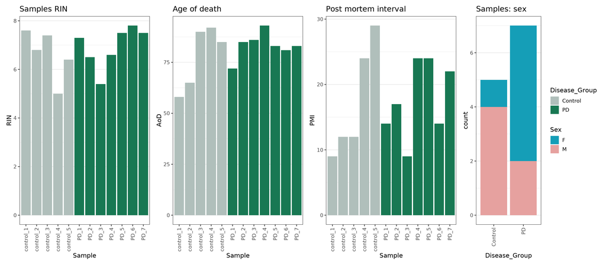

```r
RIN_bar <- metadata %>%
  ggplot(aes(x=Sample, y = RIN, fill = Disease_Group)) +
  geom_bar(stat = "identity") +
  theme_aw +
    scale_fill_manual(values = named_palette) +
  labs(title = "Samples RIN")


AOD_bar <- metadata %>%
  ggplot(aes(x=Sample, y = AoD, fill = Disease_Group)) +
  geom_bar(stat = "identity") +
  theme_aw +
      scale_fill_manual(values = named_palette) +
  labs(title = "Age of death")

PMI_bar <- metadata %>%
  ggplot(aes(x=Sample, y = PMI, fill = Disease_Group)) +
  geom_bar(stat = "identity") +
  theme_aw +
      scale_fill_manual(values = named_palette) +
  labs(title = "Post mortem interval")

sex_bar <- metadata %>%
  ggplot(aes(x=Disease_Group, fill = Sex)) +
  geom_bar(stat = "count",
           position = "stack") +
  theme_aw +
      scale_fill_paletteer_d("werpals::pan",
                        direction = -1) +
  labs(title = "Samples: sex")



(RIN_bar | AOD_bar | PMI_bar | sex_bar | plot_layout(guides = "collect", widths = c(2,2,2,1)))
```

# 5 Load edit site files

```r
# Load file of significant results
master_df <- readRDS(args$detect_summary_comparison_sig_file)
# Replace NA gene types with intergenic (in efficient manner)
master_df$gene_type[is.na(master_df$gene_type)] <- "intergenic"
master_df$Disease_Group <- factor(master_df$Disease_Group)
```

```r
#contrasts = list(PD = c("Control", "PD"))
contrast_to_explore <- c("Control", "PD")
region_to_explore <- NULL
```

# 6 Results

## 6.1 Text

In order to fulfil linearity assumptions, editing results were filtered to include those >0 and <1. Linear regression was utilised to explore relationships between PD and control brains, correcting for the covariates of RIN and sex.

```r
# Analysis and plotting code for the current region and contrast
    contrast_list <- list(Control = contrast_to_explore[1],
                          Disease = contrast_to_explore[2])
    disease = contrast_to_explore[2]

    comparison_df <- master_df %>%
        dplyr::filter(Disease_Group %in% contrast_to_explore)

    # Write output table
    summary_edits_df <- comparison_df %>%
        dplyr::select(locus, Sample, Edits, z.score)
    write_csv(summary_edits_df,
               file = str_c(args$output_folder, "/brain/sig_edits_", contrast_to_explore[1], "_", contrast_to_explore[2], ".csv"))

    # Replace NAs in genic type with intergenic, and create column of collapsed biotypes for plotting
   comparison_df <- comparison_df %>%
      dplyr::mutate(biotype_plots = as_factor(gene_biotype)) %>%
      remove_suffix_from_gene_id(., column = "gene_id")

    # Recode and reorder biotype levels for plotting
    levels(comparison_df$biotype_plots) <- vep_levels_BIOTYPE

    # Factorise locus
    comparison_df$locus <- factor(comparison_df$locus)

    # Factorise disease group, checking levels in data match levels in factor to be
         comparison_df$Disease_Group <- factor(comparison_df$Disease_Group)
    dataframe_levels <- levels(comparison_df$Disease_Group)
    if (!all(dataframe_levels %in% contrast_to_explore) && all(contrast_to_explore %in% dataframe_levels)) {
      errorCondition("Supplied sorting factor does not match disease group levels in data")
    }
    levels(comparison_df$Disease_Group) <- contrast_to_explore

    # Find sample counts and consequences for annotation later
    sample_counts <- comparison_df %>%
        ungroup() %>%
      distinct(Sample, Disease_Group) %>%
      count(Disease_Group)

    loci_consequences <- comparison_df %>%
      dplyr::select(locus, gene_name, gene_id, biotype_plots, gene_type) %>%
      dplyr::distinct(locus, .keep_all = T)

    # Filter by number of sites common within groups and between samples
    sites_to_explore <- data.table::copy(comparison_df)
    sites_to_explore <- sites_to_explore %>%
           dplyr::filter(Edits < 1)   #Filter to editing rate < 1.
    number_common_samples_per_group = 2
    site_label <- "common_2_sample"
    site_annotation <- "Sites common to 2 samples per group: "

    common_loci <- find_sites_loci_common_to_x_samples(sites_df = sites_to_explore,
                                                       sample_counts_df = sample_counts,
                                                       no_common_samples_per_site = number_common_samples_per_group )
```

```
## [1] "Control group; 5 samples"
## [1] "PD group; 7 samples"
```

```r
    sites_subset <- filter_sites_by_locus_vector(sites_df = sites_to_explore,
                                                 vector_of_loci = common_loci,
                                                 factor_list = contrast_list)


    number_sites_per_sample <- sites_subset %>%
      count(Sample) %>%
      dplyr::rename(n_sites_per_sample = n)

    sites_subset <- sites_subset %>%
      left_join(number_sites_per_sample,
                by = "Sample")


    ###  Regression by sites ####
    lm_results_sites <- regress_editing(sites_df = sites_subset,
                                        editing_metric = "Edits",
                                        covariates = covariates_used,
                                        factor_list = contrast_list,
                                        outcome_measure = outcome_to_explore,
                                        disease = disease)

    summary(lm_results_sites$lm_results_with_outcome)
```

```
##
## Call:
## lm(formula = form, data = sites_df)
##
## Residuals:
##      Min       1Q   Median       3Q      Max
## -0.39510 -0.19136 -0.03327  0.16644  0.62678
##
## Coefficients:
##                   Estimate Std. Error t value Pr(>|t|)
## (Intercept)      0.4315798  0.0021649  199.35  < 2e-16 ***
## Disease_GroupPD  0.0105022  0.0007266   14.45  < 2e-16 ***
## RIN             -0.0085222  0.0003647  -23.37  < 2e-16 ***
## SexM             0.0062319  0.0008041    7.75 9.21e-15 ***
## ---
## Signif. codes:  0 '***' 0.001 '**' 0.01 '*' 0.05 '.' 0.1 ' ' 1
##
## Residual standard error: 0.2337 on 1058511 degrees of freedom
## Multiple R-squared:  0.0007535,  Adjusted R-squared:  0.0007507
## F-statistic: 266.1 on 3 and 1058511 DF,  p-value: < 2.2e-16
```

```r
    tidy(lm_results_sites$lm_results_with_outcome, conf.int = T)
```

| term | estimate | std.error | statistic | p.value | conf.low | conf.high |
| --- | --- | --- | --- | --- | --- | --- |
| (Intercept) | 0.431579817 | 0.0021648887 | 199.354273 | 0.000000e+00 | 0.427336708 | 0.435822926 |
| Disease_GroupPD | 0.010502236 | 0.0007266204 | 14.453538 | 2.406224e-47 | 0.009078084 | 0.011926387 |
| RIN | -0.008522220 | 0.0003646560 | -23.370571 | 9.139470e-121 | -0.009236933 | -0.007807506 |
| SexM | 0.006231856 | 0.0008041235 | 7.749875 | 9.206425e-15 | 0.004655801 | 0.007807911 |

A sensitivity analysis was performed additionally covarying for the number of sites per sample.

```r
### Run regression covaried by n sites per sample
    # Regression by number of sites + n_sites_per_sample
    lm_results_sites_nsites <- regress_editing(sites_df = sites_subset,
                                               editing_metric = "Edits",
                                               covariates = c("n_sites_per_sample", covariates_used),
                                               factor_list = contrast_list,
                                               outcome_measure = outcome_to_explore,
                                               disease = disease)

summary(lm_results_sites_nsites$lm_results_with_outcome)
```

```
##
## Call:
## lm(formula = form, data = sites_df)
##
## Residuals:
##      Min       1Q   Median       3Q      Max
## -0.39303 -0.19149 -0.03337  0.16689  0.62806
##
## Coefficients:
##                      Estimate Std. Error t value Pr(>|t|)
## (Intercept)         4.374e-01  2.239e-03 195.387  < 2e-16 ***
## Disease_GroupPD     7.129e-03  7.977e-04   8.937  < 2e-16 ***
## n_sites_per_sample -1.301e-07  1.270e-08 -10.249  < 2e-16 ***
## RIN                -7.078e-03  3.909e-04 -18.105  < 2e-16 ***
## SexM                2.997e-03  8.638e-04   3.470 0.000521 ***
## ---
## Signif. codes:  0 '***' 0.001 '**' 0.01 '*' 0.05 '.' 0.1 ' ' 1
##
## Residual standard error: 0.2337 on 1058510 degrees of freedom
## Multiple R-squared:  0.0008527,  Adjusted R-squared:  0.0008489
## F-statistic: 225.8 on 4 and 1058510 DF,  p-value: < 2.2e-16
```

```r
tidy(lm_results_sites_nsites$lm_results_with_outcome, conf.int = T)
```

| term | estimate | std.error | statistic | p.value | conf.low | conf.high |
| --- | --- | --- | --- | --- | --- | --- |
| (Intercept) | 4.374309e-01 | 2.238789e-03 | 195.387325 | 0.000000e+00 | 4.330430e-01 | 4.418189e-01 |
| Disease_GroupPD | 7.128827e-03 | 7.976545e-04 | 8.937237 | 3.996371e-19 | 5.565451e-03 | 8.692203e-03 |
| n_sites_per_sample | -1.301445e-07 | 1.269772e-08 | -10.249436 | 1.193529e-24 | -1.550316e-07 | -1.052574e-07 |
| RIN | -7.077806e-03 | 3.909234e-04 | -18.105352 | 2.966336e-73 | -7.844003e-03 | -6.311610e-03 |
| SexM | 2.997200e-03 | 8.637999e-04 | 3.469785 | 5.208955e-04 | 1.304181e-03 | 4.690219e-03 |

## 6.2 Figures

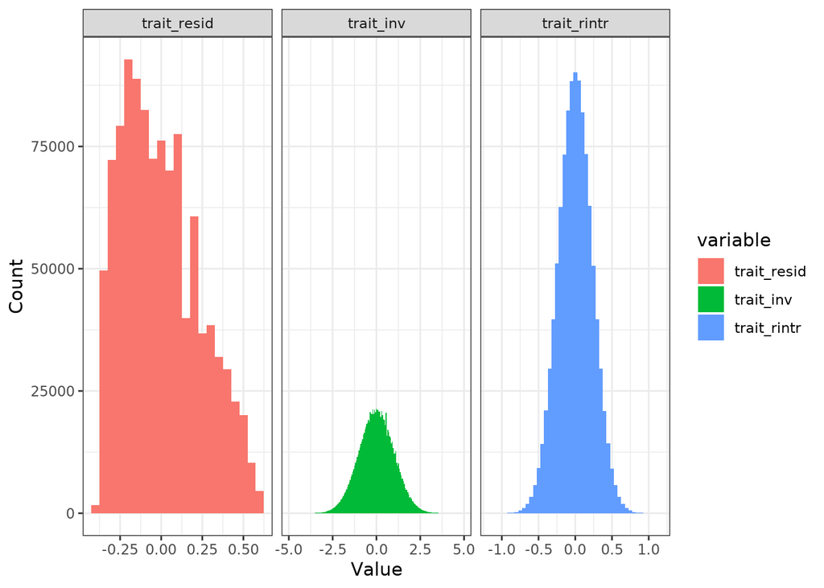

```r
# Look at residuals across different scalings
# create the residuals for trait- with covariates
rawphenos <- data.frame(trait_resid = lm_results_sites$sites_subset_residuals$.resid)

# perform the inverse-normal transform
# Step 1: Rank the residuals
ranks <- rank(rawphenos$trait_resid)

# Step 2: Apply the inverse normal transformation
# The transformation is applied such that the ranks are scaled to (0, 1), avoiding exact 0 and 1 by using (n+1) in the denominator
inverse_normal_residuals <- qnorm((ranks - 0.5) / length(rawphenos$trait_resid))
rawphenos$trait_inv <- inverse_normal_residuals

# rescale the transformed residuals to match the original trait distribution
rawphenos$trait_rintr= rawphenos$trait_inv*sqrt(var(rawphenos$trait_resid, na.rm = T))

# Reshape the dataframe to long format
rawphenos_long <- rawphenos %>%
  pivot_longer(cols = everything(), names_to = "variable", values_to = "value") %>%
    dplyr::mutate(variable = fct_relevel(variable, c("trait_resid", "trait_inv", "trait_rintr")))

# Plot side-by-side histograms
ggplot(rawphenos_long, aes(x = value, fill = variable)) +
  geom_histogram(position = "dodge", binwidth = 0.05) + # Adjust binwidth as needed
  facet_wrap(~variable, scales = "free_x") + # Separate histogram for each variable
  theme_bw() +
  labs(x = "Value", y = "Count")
```

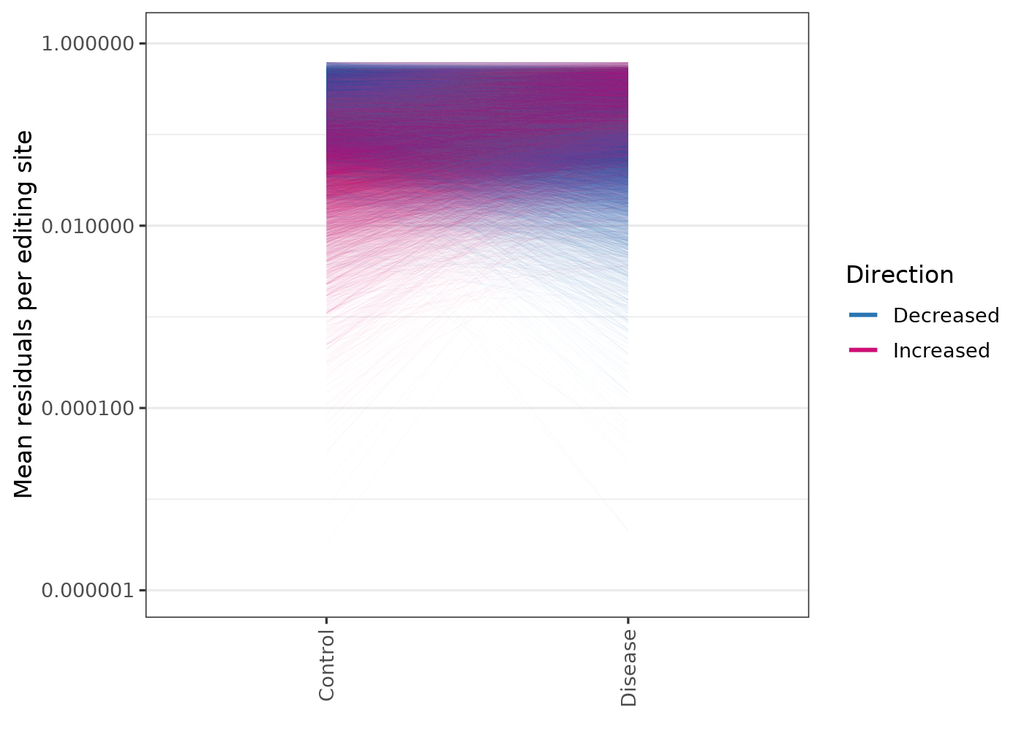

```r
total_sites_violin <- plot_site_number_violin(sites_subset, plot_label = plot_labels)

# Violin plot
 edit_resid_violin <-  lm_results_sites$sites_subset_residuals %>%
      ggplot(aes(x = Disease_Group,
             y = .resid,
             fill = Disease_Group)) +
      geom_violin(draw_quantiles = c(0.25, 0.5, 0.75)) +
      scale_fill_manual(values = named_palette,
                        labels = plot_labels) +
      scale_x_discrete(labels = plot_labels) +
      theme_aw +
      labs(fill = "Disease Group", x = NULL, y = "Residual editing rate")



 parallel_plot <- create_parallel_plot(mean_residuals_df =  lm_results_sites$mean_residuals_df,
                                       disease = disease,
                                       feature = "locus",
                                       feature_label = "editing site",
                                       scale = "log10") +
     labs(title = NULL)
 parallel_plot
```

```r
ggsave(parallel_plot,
        file = str_c(args$output_folder, "/brain/brain_parallel-line_scaled.png"),
        device = "png",
        dpi = 300,
        units = "cm",
        width = 12,
        height = 12,
        limitsize = TRUE)

ggsave(parallel_plot,
        file = str_c(args$output_folder, "/brain/brain_parallel-line_scaled.pdf"),
        device = "pdf",
        dpi = 300,
        units = "cm",
        width = 12,
        height = 12,
        limitsize = TRUE)
```

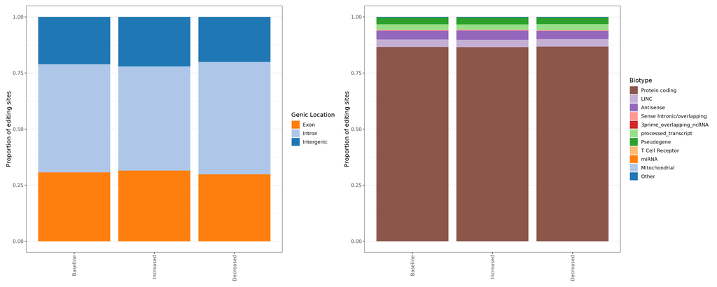

```r
## Compare baseline to change  for plotting
    compare_baseline_df <- compare_proportions_baseline_altered(lm_results_list = lm_results_sites,
                                                                loci_consequences = loci_consequences,
                                                                factor_list = contrast_list)
    genic_dif_plot <- plot_compare_proportions_baseline(compare_proportions_df = compare_baseline_df,
                                                        metric_to_plot = "gene_type",
                                                        fill_label = "Genic Location") +
        labs(subtitle = NULL)

    biotype_dif_plot <- plot_compare_proportions_baseline(compare_proportions_df = compare_baseline_df,
                                                          metric_to_plot = "biotype_plots",
                                                          fill_label = "Biotype") +
        labs(subtitle = NULL)

    (genic_dif_plot | biotype_dif_plot)
```

Exploring the change in proportion of exonic sites in differentiall edited sites using chi squared test: p value = 1.4x10^-12

```r
compare_baseline_df %>%
    dplyr::select(Direction, gene_type) %>%
     dplyr::mutate(gene_type = fct_recode(gene_type, exon = "exon", other = "intron", other = "intergenic")) %>%
    dplyr::filter(Direction != "Baseline") %>%
    droplevels() %>%
    table() %>%
    chisq.test()
```

```
##
##  Pearson's Chi-squared test with Yates' continuity correction
##
## data:  .
## X-squared = 50.179, df = 1, p-value = 1.403e-12
```

# 7 EWCE analysis

We use [expression weighted cell-type enrichment](https://nathanskene.github.io/EWCE/index.html) to explore the genes with the greatest mean change in editing to see whether those genes are enriched in any particular cell types. The specificity matrices utilised were previously derived from the single cell data from the study samples by Regina Reynolds. We explored the top 50 genes relative to the 12,017 total genes in the dataset.

## 7.1 Explore the top edited genes

```r
common_loci <- find_sites_loci_common_to_x_samples(sites_df = comparison_df,
                                                       sample_counts_df = sample_counts,
                                                       no_common_samples_per_site = number_common_samples_per_group )
```

```
## [1] "Control group; 5 samples"
## [1] "PD group; 7 samples"
```

```r
    sites_subset <- filter_sites_by_locus_vector(sites_df = comparison_df,
                                                 vector_of_loci = common_loci,
                                                 factor_list = contrast_list)


    number_sites_per_sample <- sites_subset %>%
      count(Sample) %>%
      dplyr::rename(n_sites_per_sample = n)

    sites_subset <- sites_subset %>%
      left_join(number_sites_per_sample,
                by = "Sample")


    ###  Regression by sites ####
    lm_results_sites <- regress_editing(sites_df = sites_subset,
                                        editing_metric = "Edits",
                                        covariates = covariates_used,
                                        factor_list = contrast_list,
                                        outcome_measure = outcome_to_explore,
                                        disease = disease)


dif_edits <- lm_results_sites$mean_residuals_df %>%
  left_join(loci_consequences,
            by = "locus") %>%
  arrange(desc(edit_difference_per_feature))


top_edits_sites_list <- dif_edits %>%
  distinct(gene_name) %>%
    drop_na() %>%
  unlist()

top_edits_sites_id_list <- dif_edits %>%
  distinct(gene_id) %>%
      drop_na() %>%
  unlist()

write.csv(top_edits_sites_list, file = str_c(args$output_folder,
                                             "/brain/",
                                             disease,
                                             "_top_edit_sites_list.csv"))
```

```r
dif_edits_genes <- dif_edits %>%
  group_by(gene_name, gene_id, biotype_plots) %>%
  summarise(mean_dif_edits_per_gene = mean(edit_difference_per_feature)) %>%
  arrange(desc(mean_dif_edits_per_gene))

top_edits_genes_list <- dif_edits_genes %>%
  ungroup() %>%
  dplyr::select(gene_name) %>%
  unlist()

top_edits_genes_id_list <- dif_edits_genes %>%
  ungroup() %>%
  dplyr::select(gene_id) %>%
  unlist()

write.csv(top_edits_genes_list, file = str_c(args$output_folder,
                                             "/brain/",
                                             disease,
                                             "_top_edit_genes_list.csv"))
```

### 7.1.1 EWCE analysis

```r
top_edits_genes_list <- read.csv(file =  str_c(args$output_folder,
                                             "/brain/",
                                             disease,
                                             "_top_edit_genes_list.csv")) %>%
    dplyr::select(x) %>%
    unlist()

# Load internal specificity matrices
ctd_files <-
  list.files(
    file.path(
      args$output_folder,
      "brain",
      "acta_snRNA_specificity_matrix_march2020"
    ),
    pattern = "ctd",
    full.names = T)


ctd_list <- vector(mode = "list", length = length(ctd_files))

for(i in 1:length(ctd_files)){

  # Load ctd
  ctd_list[[i]] <- readRDS(ctd_files[i])

  # Extract file name
  title <-
    ctd_files[i] %>%
    str_replace(".*/", "") %>%
    str_replace("\\..*", "") %>%
    str_replace(".*_", "")

  # Name list
  names(ctd_list)[i] <- title

}

rep_number = 10000
annot_level = 1
set.seed(234)

top_gene_n  = 50
ctd_dataset = ctd_list[[disease]]
```

#### 7.1.1.1 Relative to PD Brain

Genes that contain the greatest difference in mean editing rate per gene between control and PD

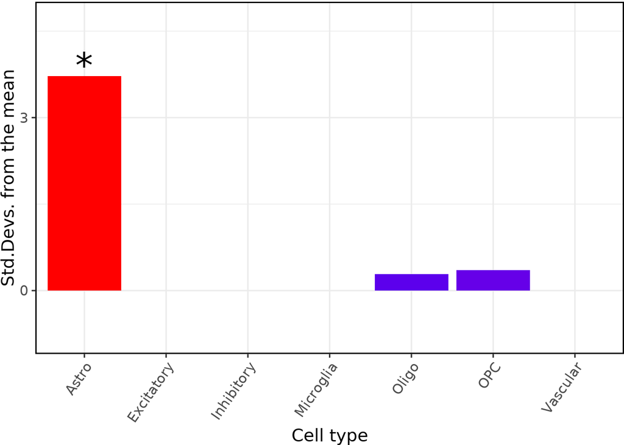

```r
ctd_dataset = ctd_list[[disease]]
ewce_genes <- EWCE::bootstrap_enrichment_test(sct_data = ctd_dataset,
                                                sctSpecies = "human",
                                                genelistSpecies = "human", no_cores = 16,
                                                 hits = top_edits_genes_list[1:top_gene_n], bg = top_edits_genes_list,
                                                reps = rep_number,
                                                annotLevel = annot_level)
plot_list <- EWCE::ewce_plot(total_res = ewce_genes$results,
                           mtc_method = "BH",
                           ctd = ctd_dataset)
plot_list[[1]]
```

```r
ewce_genes$results
```

|  | CellType | annotLevel | p | fold_change | sd_from_mean | q |
| --- | --- | --- | --- | --- | --- | --- |
| Astro | Astro | 1 | 0.0006 | 1.3985420 | 3.7230565 | 0.0042 |
| OPC | OPC | 1 | 0.3294 | 1.0324480 | 0.3557585 | 0.8540 |
| Oligo | Oligo | 1 | 0.3660 | 1.0305914 | 0.2876212 | 0.8540 |
| Excitatory | Excitatory | 1 | 0.7429 | 0.9317337 | -0.6746964 | 0.9568 |
| Vascular | Vascular | 1 | 0.7714 | 0.9057021 | -0.7829413 | 0.9568 |
| Inhibitory | Inhibitory | 1 | 0.8389 | 0.9119696 | -0.9795943 | 0.9568 |
| Microglia | Microglia | 1 | 0.9568 | 0.8133960 | -1.5232794 | 0.9568 |

```r
saveRDS(ewce_genes,
        file = str_c(args$output_folder, "/brain/EWCE_results_top50_meangene_cf_PD.RDS"))
```

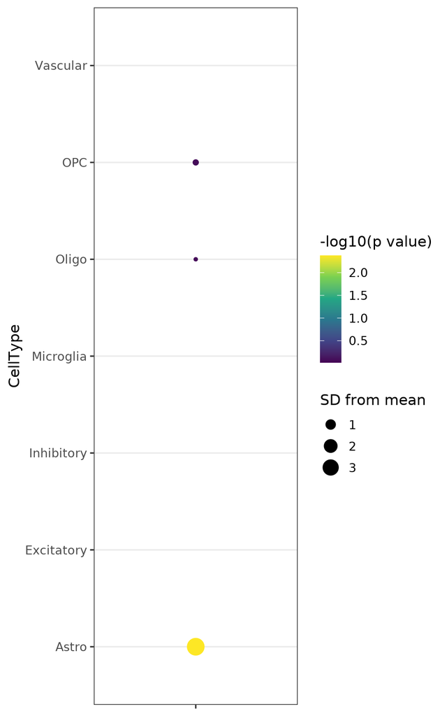

```r
ewce_genes <- readRDS(str_c(args$output_folder, "/brain/EWCE_results_top50_meangene_cf_PD.RDS"))

ewce_figure <- ewce_genes$results %>%
    dplyr::mutate(sd_from_mean = ifelse(sd_from_mean < 0, NA, sd_from_mean),
                  annotLevel = factor(annotLevel),
                  log10p = -log10(q)) %>%
    ggplot(aes(y= CellType, x = annotLevel, size = sd_from_mean, colour = log10p)) +
    geom_point() +
    scale_x_discrete(labels = element_blank()) +
  #  scale_colour_continuous(trans = "log10") +
    scale_colour_viridis_c() +
    theme_aw +
    theme(legend.position = "right") +
    labs(colour = "-log10(p value)", size = "SD from mean", x = NULL)

ewce_figure
```

```r
ggsave(ewce_figure,
        file = str_c(args$output_folder, "/brain/brain_ewce_figure_top50_cf_pdbrain_rightlegend.png"),
        device = "png",
        dpi = 300,
        units = "cm",
        width = 10,
        height = 12,
        limitsize = TRUE)

ggsave(ewce_figure,
        file = str_c(args$output_folder, "/brain/brain_ewce_figure_top50_cf_pdbrain_rightlegend.pdf"),
        device = "pdf",
        dpi = 300,
        units = "cm",
        width = 10,
        height = 12,
        limitsize = TRUE)
```

```r
ewce_figure_bottom <- ewce_figure + theme(legend.position = "bottom")
ggsave(ewce_figure_bottom,
        file = str_c(args$output_folder, "/brain/brain_ewce_figure_top50_cf_pdbrain_bottomlegend.png"),
        device = "png",
        dpi = 300,
        units = "cm",
        width = 18,
        height = 12,
        limitsize = TRUE)

ggsave(ewce_figure_bottom,
        file = str_c(args$output_folder, "/brain/brain_ewce_figure_top50_cf_pdbrain_bottomlegend.pdf"),
        device = "pdf",
        dpi = 300,
        units = "cm",
        width = 18,
        height = 12,
        limitsize = TRUE)
```

```r
ggsave(ewce_figure,
        file = str_c(args$output_folder, "/brain/brain_ewce_figure_top50_cf_pdbrain_rightlegend.png"),
        device = "png",
        dpi = 300,
        units = "cm",
        width = 12,
        height = 18,
        limitsize = TRUE)

ggsave(ewce_figure,
        file = str_c(args$output_folder, "/brain/brain_ewce_figure_top50_cf_pdbrain_rightlegend.pdf"),
        device = "pdf",
        dpi = 300,
        units = "cm",
        width = 12,
        height = 12,
        limitsize = TRUE)
```

[output not shown]

[figure not shown]

```r
ewce_genes_control$results
```

|  | CellType | annotLevel | p | fold_change | sd_from_mean | q |
| --- | --- | --- | --- | --- | --- | --- |
| Astro | Astro | 1 | 0.0029 | 1.3362652 | 3.16947574 | 0.02030 |
| Oligo | Oligo | 1 | 0.2465 | 1.0699051 | 0.65389637 | 0.86275 |
| OPC | OPC | 1 | 0.4621 | 1.0012680 | 0.01471042 | 0.91170 |
| Vascular | Vascular | 1 | 0.7378 | 0.9152751 | -0.67883278 | 0.91170 |
| Excitatory | Excitatory | 1 | 0.7890 | 0.9202088 | -0.81942258 | 0.91170 |
| Microglia | Microglia | 1 | 0.8416 | 0.8914571 | -0.99355266 | 0.91170 |
| Inhibitory | Inhibitory | 1 | 0.9117 | 0.8838747 | -1.30255569 | 0.91170 |

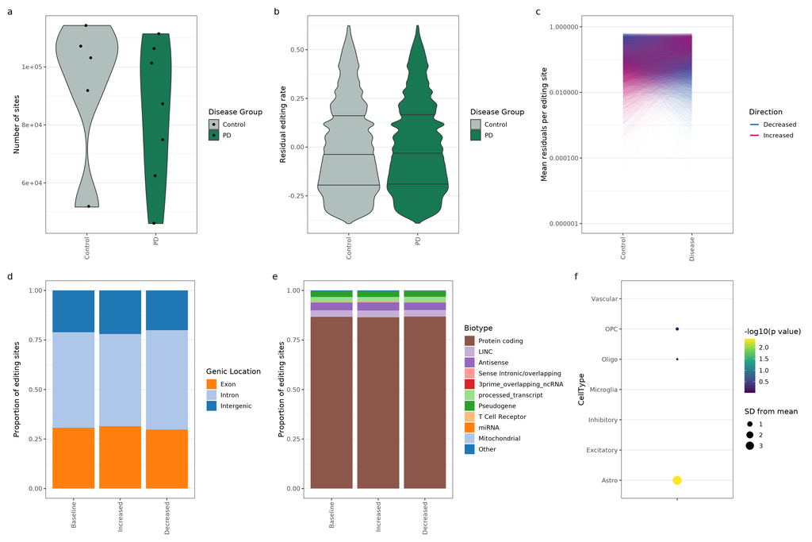

```r
supp_7_figure <- ((total_sites_violin +  edit_resid_violin +  parallel_plot) /
    (genic_dif_plot +  biotype_dif_plot + ewce_figure + plot_layout(widths = c(2, 2, 1.5)))) +
    plot_annotation(tag_levels = "a")
  #  +plot_annotation(tag_levels = list(c("d", "e", "f", "g", "h", "i", "j")))

supp_7_figure
```

```r
ggsave(supp_7_figure,
       file = str_c(args$output_folder, "/brain/supp_7_figure.pdf"),
       device = "pdf",
       dpi = 300,
       units = "mm",
       width = 300,
       height = 180,
       limitsize = TRUE
)

ggsave(supp_7_figure,
       file = str_c(args$output_folder, "/brain/supp_7_figure.png"),
       path = args$figure_output_dir,
       device = "png",
       dpi = 300,
       units = "mm",
       width = 300,
       height = 180,
       limitsize = TRUE
)
```